# RMarkdown Class Schedule

Nelson Huang

September 12, 2019

# Class Schedule

### PSU 016: First-Year Seminar

This class is a chance for first-year students to get acclamated to college life. Each department at Penn State has their own section(s) of PSU 016, so students can take the class with other first-year students in their major. I enjoy teaching the first-year seminar because it’s a great opportunity to me to get to know the new class of Statistics Majors! This year I’m trying something different by assigning the book “How Not to Be Wrong” by Jordan Ellenberg. It’s a really great book about how I think statisticians/mathematicians see the world differently from most other people. I hope the class actually enjoys it.

For some reason I admit that I was a little surprised to find a Wikipedia page about first-year seminar classes at American Universities, but [here’s the link](https://en.wikipedia.org/wiki/The_First_Year_Experience_Program)! The page doesn’t currently have a picture, so a classic Penn State picture of Old Main seems as fitting as anything else.

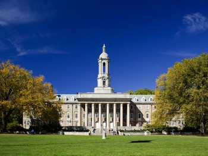

### STAT 184: Introduction to R Programmaing

This semester, I am enrolled in STAT 184. So far, it’s an interesting couple of weeks. I copmleted a couple of assignments about “Tidy Data” and how it can be used to organize variables in various datasets. In addition, I have the unique opportunity to learn a new programming language in R, which is really exciting because I never really touched on this before. I do have experience coding in Python, Java and C++, but it’s always fun to expand that knowledge and learn something new. From my observation, Python programming language is similar to R such that their syntaxes are almost identical. I’m definitely looking forward to learn more about R and how it can be used in statistics.

### CMPSC 442: Intro to Artificial Intelligence

Another course I am taking this semester is CMPSC 442, which is an introduction to artificial intelligence. The first week of the semester was a review of some basic Python topics, including list comprehensions, generators and object oriented programming. We are currently learning about intelligent agents and how any agent would act on a certain environment.

It’s a really interesting topic, which can be read more at [this](https://en.wikipedia.org/wiki/Intelligent_agent) Wikipedia page.

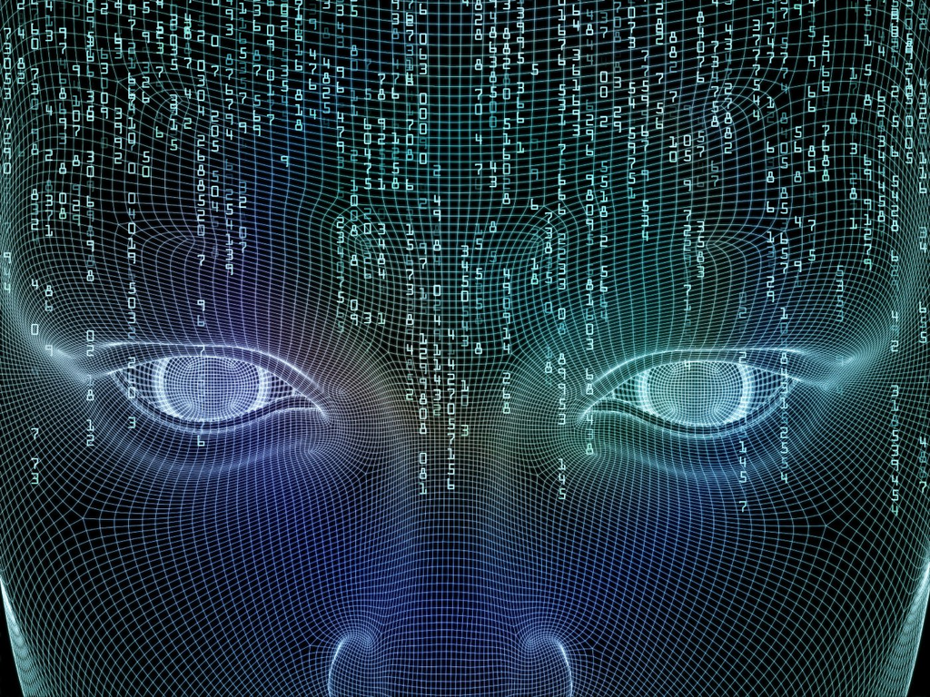

### IST 250: Introduction to Web Design and Development

Another course I am taking this semester is IST 250, which is an introduction to web design and web development. This is definitely a course I’m looking forward to because it is close to my area of expertise. During the first week of class, we learned the basics of HTML and how the world wide web operates. The pace of the lesson was a bit slow for me, but we immediately moved on to learn CSS the next several days. This was a bit strange for me, but I’m assuming, and hoping, we are learning both HTML and CSS concurrently.

This Wikipedia [page](https://en.wikipedia.org/wiki/Web_development) has some interesting information about web development, in general.

[figure not shown]

### CMPEN 454: Fundamentals of Computer Vision

And lastly, another course I’m taking this semester is CMPEN 454. This is a Computer Vision course that talks about how computer projects various graphics and the mathematical concepts behind such development. There is a lot linear algebra involved because computer graphics can be represente with a matrix. Each pixel can be represented by numbers, which is just the hex code for a certain combination of colors. How a graphic moves is all dependent on the computer’s CPU to compute various computations.

To learn more, visit this Wikipedia [page](https://en.wikipedia.org/wiki/Computer_vision).

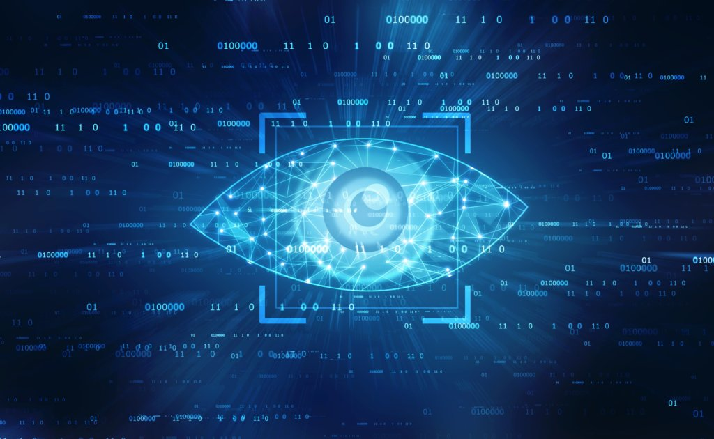